# Homework #5

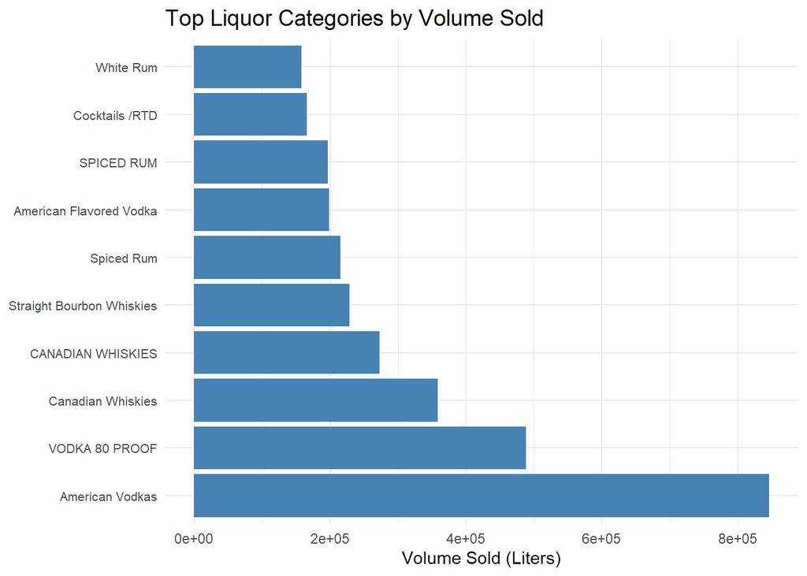

```r
# For the liquor category breakdown
# Create a summarized dataset for plotting
category_summary <- data %>%
  group_by(`Category Name`) %>%
  summarise(`Volume Sold (Liters)` = sum(`Volume Sold (Liters)`)) %>%
  arrange(desc(`Volume Sold (Liters)`)) %>%
  mutate(`Category Name` = factor(`Category Name`, levels = `Category Name`))

# Plot the top N categories for clarity
top_n_categories <- 10  # or another number that fits well in your plot area
ggplot(category_summary %>% top_n(top_n_categories, `Volume Sold (Liters)`),
       aes(x = `Category Name`, y = `Volume Sold (Liters)`)) +
  geom_bar(stat = "identity", fill = "steelblue") +
  coord_flip() +  # Flip coordinates for horizontal bars
  labs(x = "", y = "Volume Sold (Liters)", title = "Top Liquor Categories by Volume Sold") +
  theme_minimal() +
  theme(
    axis.text.y = element_text(size = 8),
    axis.title.y = element_blank(),
    plot.title = element_text(size = 14)
  )
```

```r
# Execute this code in your R environment and adjust the 'top_n_categories' value if needed
# to ensure all labels are readable.
```

5. (3 pts) Find the daily liquor sales in Ames in 2021: summarize number of sales, volume of liquor sold and amount of money spent. Plot volume sold by day (use a scatterplot of volume by day and facet by month). Describe any patterns. Find the dates for ISU football home games in Fall 2021. Can you see a pattern? Describe your finding.

```r
# Filter data for the year 2021
liquor_sales_2021 <- data %>%
  filter(Year == 2021)

# Summarize daily liquor sales for 2021
daily_sales_summary <- liquor_sales_2021 %>%
  group_by(Date) %>%
  summarise(
    Number_of_Sales = n(),
    Total_Volume_Sold = sum(`Bottles Sold` * `Bottle Volume (ml)`),
    Total_Amount_Spent = sum(`Sale (Dollars)`)
  )

# Load the ggplot2 package for plotting
library(ggplot2)

# Check if there are valid values for the Date variable
if (!all(is.na(daily_sales_summary$Date))) {
  # Plot volume sold by day, facet by month using facet_grid
  ggplot(daily_sales_summary, aes(x = Date, y = Total_Volume_Sold)) +
    geom_point() +
    facet_grid(. ~ format(Date, "%B"), scales = "free_x") +
    labs(x = "Date", y = "Total Volume Sold", title = "Volume Sold by Day in 2021")
} else {
  # Handle the case where there are no valid Date values
  print("No valid Date values for faceting.")
}
```

```
## [1] "No valid Date values for faceting."
```

[figure not shown]

```r
# Define ISU football home game dates in Fall 2021
isu_football_games <- data.frame(
  Date = as.Date(c(
    "2021-09-04", "2021-09-11", "2021-09-18", "2021-09-25",
    "2021-10-02", "2021-10-09", "2021-10-23", "2021-11-06",
    "2021-11-20"
  ))
)

# Merge with the daily sales summary data
daily_sales_summary_with_games <- merge(daily_sales_summary, isu_football_games, by = "Date", all.x = TRUE)

# Identify the ISU football game days in the plot
ggplot(daily_sales_summary_with_games, aes(x = Date, y = Total_Volume_Sold)) +
  geom_point() +
  geom_vline(data = isu_football_games, aes(xintercept = as.numeric(Date)), color = "red", linetype = "dashed") +
  facet_grid(. ~ format(Date, "%B"), scales = "free_x") +
  labs(x = "Date", y = "Total Volume Sold", title = "Volume Sold by Day in 2021 (ISU Football Games Highlighted)")
```

[output not shown]